# Analyzing Burki’s Performances for Borussia Dortmund

Roman Burki has had a very up and down time as BVB goalkeeper, going fro much maligned, to the star of the show, and back again. At this point, it’s a little hard to work out exactly what the view of him is among fans. But it seems as though it is net negative.

Generally speaking, when it comes to fan judgments, I find myself on the outside looking in. I think fans tend to be a little too reactionary, having a positive view one week, followed by a negative the following week. But in Burki’s case, I’ve been on the ride along with everyone else. I’m still not really sure how I feel about him.

However, my inkling is that he is a good but not good enough goalkeeper.

## Loading & Preparing Data

```r
# wrangling
total_comp <- burki %>%
  group_by(player, surname) %>%
  summarise(
    mins = sum(mins), psxg = sum(psxg), psxg90 = mean(psxg90),
    psxg_sot = mean(psxg_sot), psxg_plus_minus = sum(psxg_plus_minus),
    ga = sum(ga), ga90 = mean(ga90), sota = sum(sota), sota90 = mean(sota90),
    cross_stp = sum(cross_stp), cross_stp_perc = mean(cross_stp_perc, .groups='keep')
  ) %>%
  filter(mins > 3000)
```

## Analyzing Goalkeeper Performance from 17/18 to 20/21

### Post-Shot Expected Goals

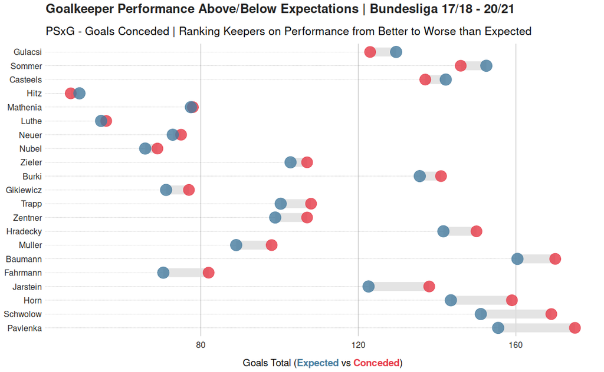

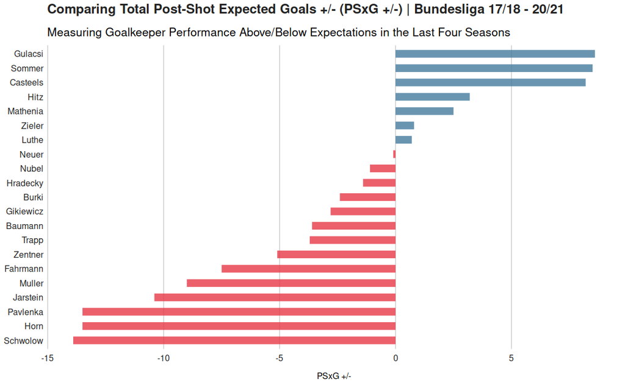

### Shot-Stopping & Workload

[figure not shown]

### Considering a Goalkeeper’s Other Responsibilities

- Look at distribution, actions outside the penalty area, and claiming crosses
- Use measures of ball progression, contribution to buildup, and maybe chance creation for distribution (as well as looking at pass completion, touches etc. to show their involvement)
- When looking at actions outside the penalty area, also look at the number of shots they’re facing, and maybe look at the team touches in defensive and mid third to consider whether the goalkeeper affords team a chance to play a higher line?
- What about claiming crosses?

## Analyzing Performance So Far This Season

- Less detailed analysis looking at Burki’s performances so far this season, and considering how he compares to others?

### Distribution & Claiming Crosses